## Homework 2

This homework uses Austin housing data from the `txhousing` data set available in R. I have already isolated the Austin housing data and placed it in a data frame called `atxhousing`. Each observation in the data frame contains information from one month of housing sales in Austin. This information includes the year, the month, number of houses sold in that month (`sales`), the total value of houses sold in dollars (`volume`), the median house price in dollars (`median`), the number of listings on the market at the end of the month (`listings`), the amount of time that it would take to sell all of the current listings at the current rate of sales (`inventory`), and the date in years in a precise decimal form (`date`).

```r
atxhousing <- txhousing[txhousing$city == 'Austin', ]
head(atxhousing)
```

```
##       city year month sales    volume median listings inventory     date
## 562 Austin 2000     1  1025 173053635 133700     3084       2.0 2000.000
## 563 Austin 2000     2  1277 226038438 134000     2989       2.0 2000.083
## 564 Austin 2000     3  1603 298557656 136700     3042       2.0 2000.167
## 565 Austin 2000     4  1556 289197960 136900     3192       2.1 2000.250
## 566 Austin 2000     5  1980 393073774 144700     3617       2.3 2000.333
## 567 Austin 2000     6  1885 368290072 148800     3799       2.4 2000.417
```

**Question 1: (3 pts)** Use ggplot2 to create a line plot of the median housing prices in Austin over time. In the same plot, fit a curve to these data using `geom_smooth()`. In one sentence, what broad trend do you observe in median housing prices over time? **HINT:** Use the `date` column as a measurement of time.

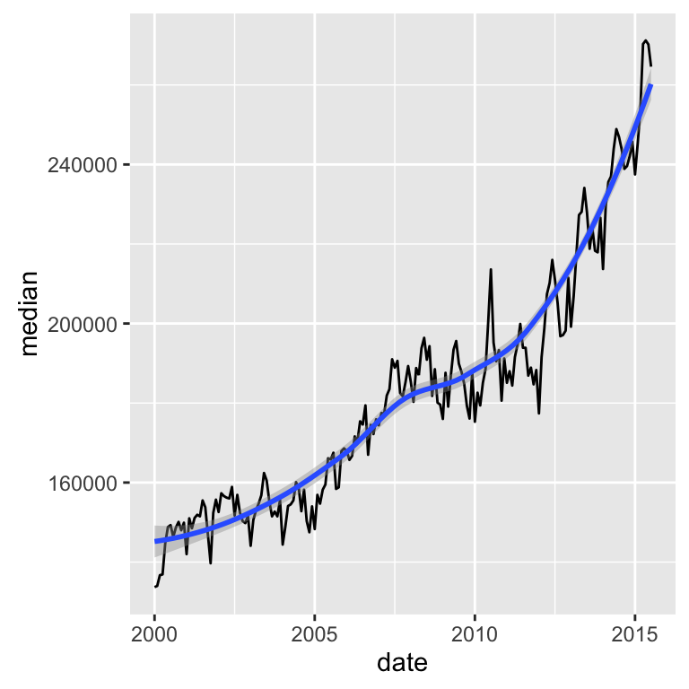

```r
ggplot(atxhousing, aes(x = date, y = median)) + geom_line() + geom_smooth()
```

Median housing prices are increasing.

**Question 2: (3 pts)** Next, create a line plot of the number of sales per month over time, facetted by year. In general, assuming that Month 1 is January, Month 2 is February, and so on, is the number of homes sold higher in the summer or the winter? State your answer in one sentence.

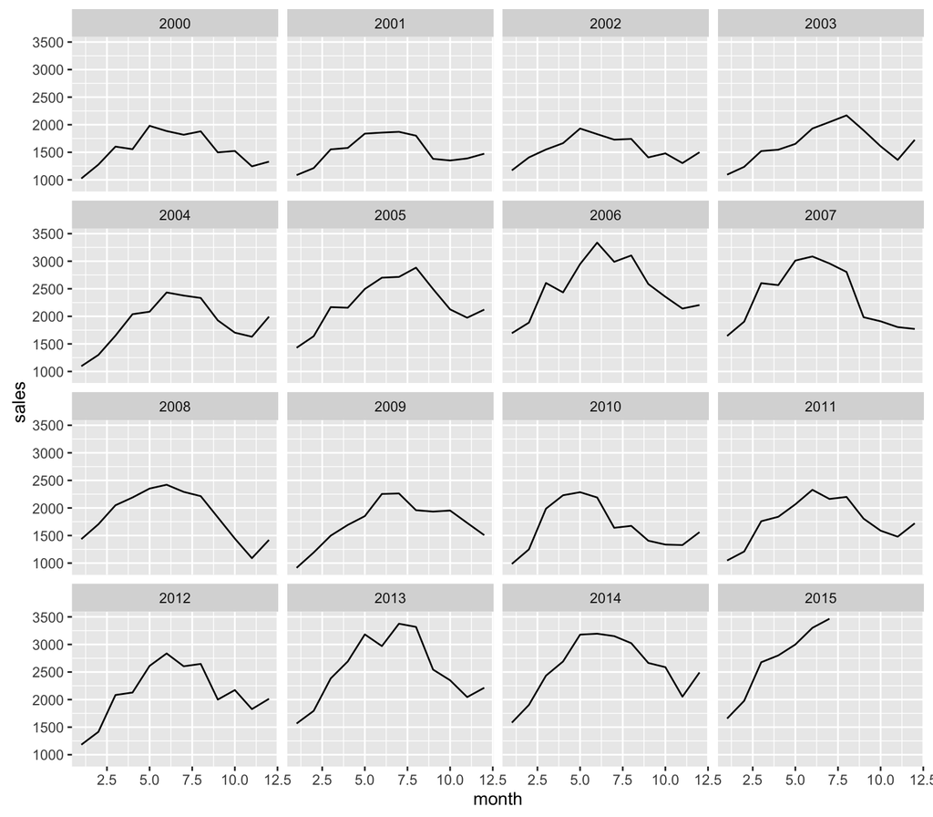

```r
ggplot(atxhousing, aes(x = month, y = sales)) + geom_line() + facet_wrap(~ year)
```

The number of homes sold per month is generally higher in the summer.

**Question 3: (2 pts)** Make up a simple data set (5-10 data points) and plot it twice, once using `geom_histogram()` and once using `geom_density()`.

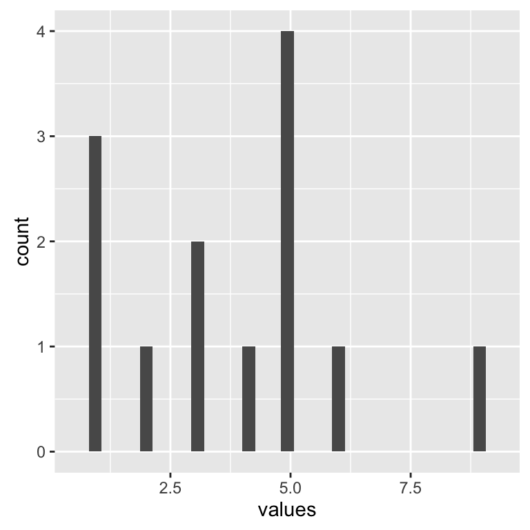

```r
mydata <- data.frame(values=c(1,1,2,3,4,5,5,5,6,3,5,9,1))

ggplot(mydata, aes(x=values)) +
  geom_histogram()
```

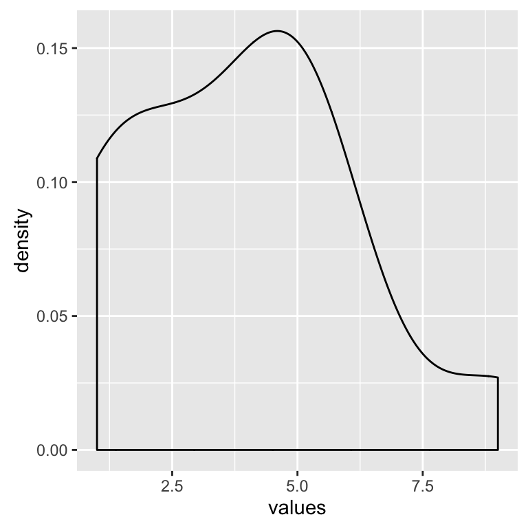

```r
ggplot(mydata, aes(x=values)) +
  geom_density()
```

**Question 4: (2 pts)** What does the y-axis in your histogram represent? In your density plot, what is the *total* area under the curve? Please give a single number as your answer. **HINT**: You do not need to do any additional calculations to determine the area under the curve.

The y-axis in a histogram represents counts in a given range of x-values (bins). The area under the curve of a density plot always sums to 1.